# Lab assignment 5

```r
library(tidyverse)
library(forcats)
library(dplyr)
```

## Alienchef

In this competition, two chefs have to prepare a soup as fast as possible. They are timed on how fast they can chop vegetables and how fast they can cook them.

The dataset in the file `alienchef.csv` reports the times in seconds for chefs `Scraf` and `Blorg`.

```r
alienchef <- read_csv("alienchef.csv")
```

- Build a stacked bar chart where the `time` is mapped to `y`, the `chef` is mapped to `x` and the `task` is encoded with `fill`.
  - If you want to convey the message that both chefs employ approximately the same time to cook the vegetables, how would you organize the stacked columns?

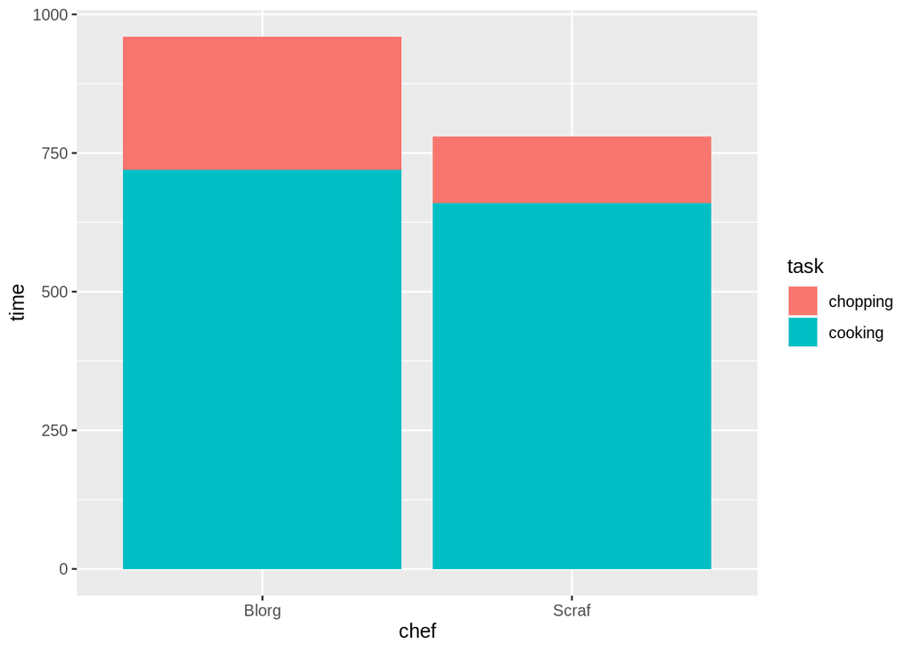

```r
# your code here
alienchef %>%
  ggplot(aes(x=chef, y = time, fill = task)) +
  geom_col()
```

- If instead, you wanted to stress that Scraf is faster at chopping, how whould you organize the columns (*hint*: use `fct_reorder`)?

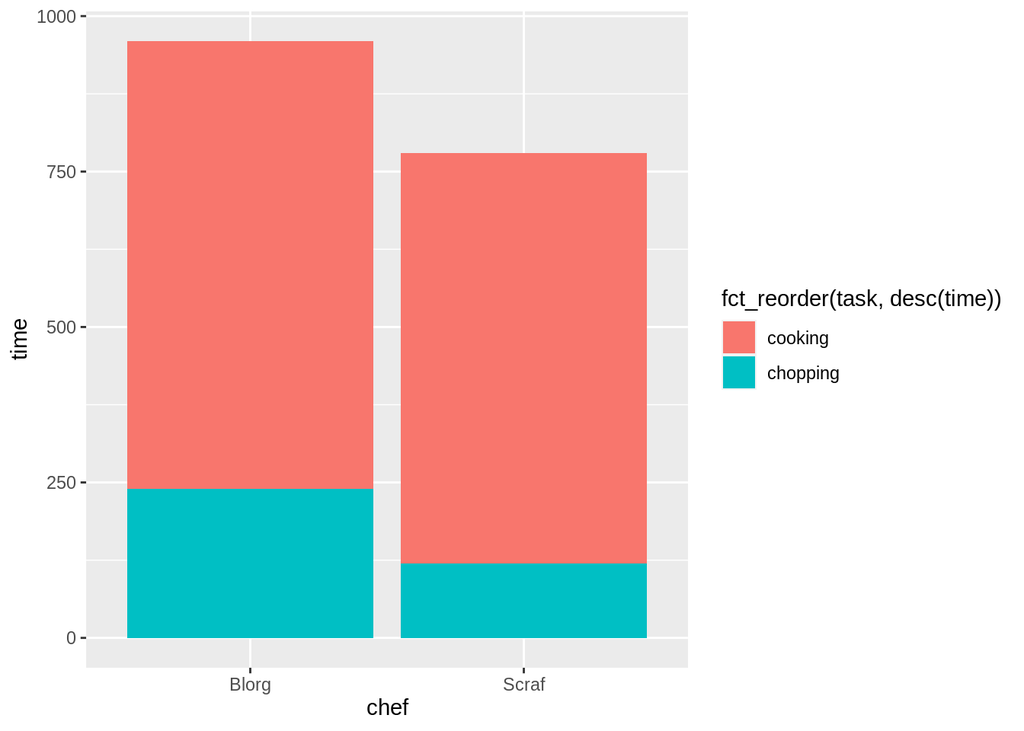

```r
# your code here
ggplot(alienchef, mapping = aes(fill = fct_reorder(task, desc(time)),
                                y = time,
                                x = chef)) +
  geom_col()
```

## US politics

The `gss_cat` dataset, from the `forcats` package contains information about surveys in the US from 2000 to 2014. Among the several columns, the `partyid` column reports the party that each survey respondent belongs to. The type of this columns is `factor`.

```r
# Get the distinct values of `partyid` using the `distinct` function from `dplyr`.
forcats::gss_cat
```

| year | marital | age | race | rincome | partyid | relig | denom | tvhours |
| --- | --- | --- | --- | --- | --- | --- | --- | --- |
| 2000 | Never married | 26 | White | $8000 to 9999 | Ind,near rep | Protestant | Southern baptist | 12 |
| 2000 | Divorced | 48 | White | $8000 to 9999 | Not str republican | Protestant | Baptist-dk which | NA |
| 2000 | Widowed | 67 | White | Not applicable | Independent | Protestant | No denomination | 2 |
| 2000 | Never married | 39 | White | Not applicable | Ind,near rep | Orthodox-christian | Not applicable | 4 |
| 2000 | Divorced | 25 | White | Not applicable | Not str democrat | None | Not applicable | 1 |
| 2000 | Married | 25 | White | $20000 - 24999 | Strong democrat | Protestant | Southern baptist | NA |
| 2000 | Never married | 36 | White | $25000 or more | Not str republican | Christian | Not applicable | 3 |
| 2000 | Divorced | 44 | White | $7000 to 7999 | Ind,near dem | Protestant | Lutheran-mo synod | NA |
| 2000 | Married | 44 | White | $25000 or more | Not str democrat | Protestant | Other | 0 |
| 2000 | Married | 47 | White | $25000 or more | Strong republican | Protestant | Southern baptist | 3 |

[output cut: 9990 more lines]

[output not shown]

```r
gss_cat%>%
distinct(partyid)
```

| partyid |
| --- |
| Ind,near rep |
| Not str republican |
| Independent |
| Not str democrat |
| Strong democrat |
| Ind,near dem |
| Strong republican |
| Other party |
| No answer |
| Don't know |

[output not shown]

You see that there 10 different parties. These might be too many for a visualization. The function `fct_collapse` from `forcats` allows you to collapse the levels of a factor in several manually specified groups. After reading the help page for `fct_collapse`, complete the following code snippet

```r
gss_cat %>%
  mutate(partyid = fct_collapse(partyid,
    other = c("No answer", "Don't know", "Other party"),
    republican = c("Strong republican", "Not str republican") ,
    independent = c("Ind,near rep", "Independent", "Ind,near dem"),
    democrat = c("Not str democrat", "Strong democrat")
  ))%>%
  # use the `count` function to compute the number of people
  # for each year and partyid
count(partyid)
```

| partyid | n |
| --- | --- |
| other | 548 |
| republican | 5346 |
| independent | 8409 |
| democrat | 7180 |

[output not shown]

Now that we have reduced the number of categories, plot how the proportion of democrats, republicans, independent, and “other” changed throught the years. You can use `geom_area` with the `"fill"` position for this task.

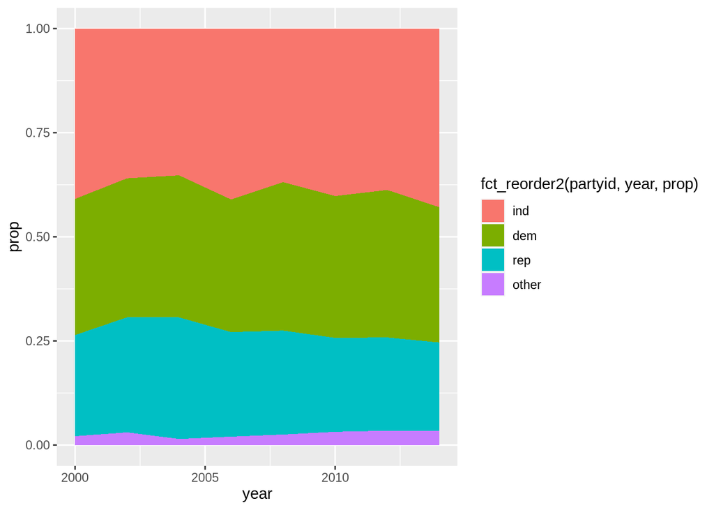

```r
# Your code here
gss_cat %>%
  mutate(partyid =
           fct_collapse(partyid,
                        other = c("No answer", "Don't know", "Other party"),
                        rep = c("Strong republican", "Not str republican"),
                        ind = c("Ind,near rep", "Independent", "Ind,near dem"),
                        dem = c("Not str democrat", "Strong democrat"))) %>%
  count(year, partyid)  %>%
  group_by(year) %>%
  mutate(prop = n /sum(n)) %>%
  ggplot(aes(x = year, y = prop,
             fill = fct_reorder2(partyid, year, prop))) +
  geom_area(position = "fill")
```

If we were to use the original categories for `partyid`, what problem would we have when making the plot?